# Untitled

Truc Huynh

4/11/2021

# Part A:

```r
library(seqinr)

# Source code for clean Alignment and print Multiple Alignment function
source("cleanAlignment.R")
source("printMultipleAlignment.R")
```

## Question 1

Retrieve the protein sequences with the following accession numbers: YP_009725305, YP_009724395, YP_009725297, QIS60515, QIS60539, QIS60709

```r
# Read the fasta file in to review it
virus <- read.fasta("VIRUS.FASTA")
```

Instead of using swissprot, I will download all that protein sequences by using the NCBI website by the following steps: - Search for the protein sequences by accession number - Add each of them to the basket. - Download all when done in fasta file format - Open each file and put them together

## Question 3

Read the alignment into R and compute the score of the alignment

```r
# Read in Multiple Alignment Sequences
obj<-read.alignment(file="VIRUS.phy", format = 'phylip')

# Download all the column scores  to file using ClustalX
# Read the scores using read.table
scores <- read.table(file="scores.qscores")

# use the mean to calculate the average score
mean(scores$V7)
```

```
## [1] 16.51934
```

## Question 4

Print the first 40 characters of the alignment.

```r
# Print the first 40 characters of the alignmnet Object using Substring
for (i in 1:6)
{
 print( substr(obj[["seq"]][[i]],1,40))
}
```

```
## [1] "--------------mkiilflalit--latcelyhyqecv"
## [1] "--------------mkiilflalit--latcelyhyqecv"
## [1] "--------------mkiilflalit--latcelyhyqecv"
## [1] "--------------nnelspvalrq--mscaagttqtact"
## [1] "--------------mkflvflgiittvaafhqecslqsct"
## [1] "meslvpgfnekthvqlslpvlqvrdvlvrgfgdsveevls"
```

```r
cat("\n")
```

```r
print("Using Multiple Alignment Printting with chunk size = 40")
```

```
## [1] "Using Multiple Alignment Printting with chunk size = 40"
```

```r
cat("\n")
```

```r
# Can also use the printMultipleAlignment
# Use the print Multiple Alignment with chunksize = 40 to print the alignment
printMultipleAlignment(obj,40)
```

```
## [1] "--------------MKIILFLALIT--LATCELYHYQECV 24"
## [1] "--------------MKIILFLALIT--LATCELYHYQECV 24"
## [1] "--------------MKIILFLALIT--LATCELYHYQECV 24"
## [1] "--------------NNELSPVALRQ--MSCAAGTTQTACT 24"
## [1] "--------------MKFLVFLGIITTVAAFHQECSLQSCT 26"
## [1] "MESLVPGFNEKTHVQLSLPVLQVRDVLVRGFGDSVEEVLS 40"
## [1] " "
## [1] "RGTTVLLKEPC--------SSGTYEGNSPFHPLADNKFAL 56"
## [1] "RGTTVLLKEPC--------SSGTYEGNSPFHPLADNKFAL 56"
## [1] "RGTTVLLKEPC--------SSGTYEGNSPFHPLADNKFAL 56"
## [1] "DDNALAYYNTT--------KGGRFV-LALLSDLQDLKWAR 55"
## [1] "QHQPYVVDDPC--------PIHFYS--KWYIRVGARKSAP 56"
## [1] "EARQHLKDGTCGLVEVEKGVLPQLEQPYVFIKRSDARTAP 80"
## [1] " "
## [1] "TCFSTQFAFACPDGVKHVY---QLRARSVSPKLFIRQEEV 93"
```

[output cut: 20 more lines]

## Question 5

# Part B:

## Question 1

Read the sequence data and store them in a FASTA file

There is 2 way to do this: ### Using Clusatx: - Read the .txt file into clustalX. - Save the file as a .FASTA file (export) ### Using R

```r
data <- read.table("~/source/R_for_Bioinformatic/R_Bioinformatic_Basic/L10/data.txt", quote="\"", comment.char="")

# Check the dimension and overview of the data
View(data)

# Write the file to the fasta file
write.fasta(list(data[2,],data[4,],data[6,],data[8,],data[10,],data[12,],data[14,]),list(data[1,],data[3,],data[5,],data[7,],data[9,],data[11,],data[13,]),file.out = "dataR.fasta")
```

Both methods return the same result

## Question 2

Use CLUSTAL program to align the sequences. Use a penalty for a gap opening equals 15 and a gap extension to be 3

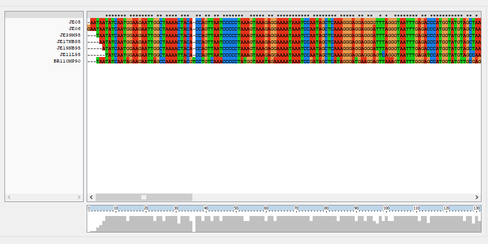

## Question 3

Read the alignment in R and print the first 20 positions of the alignment for only the first 3 sequences

## Question 4

Write a function to filter the alignment and keep only poorly conserved regions. Your function should accept two parameters: the alignment object, and the minimum percent of letters in an alignment column that must be gap characters for the column to be kept. ## Question 5 Test the function in part (B-4) using the alignment in part (B-2) considering at least 75% of gap in a position. Comment on the output ## Question 6 Find the genetic distance of the alignment